# Regression in Prediction

**Course:** HUDK 4050, Week 5

**Author:** Zhichun Liu

**Assignment:** ICE3

**Objectives:**

At the end of this ICE, you will be able to:

1. build a simple linear regression model to fit data
2. build a multiple regression model to fit data
3. report the results of regression analysis

Hopefully, the previous ICEs have given a good introduction on some basic data manipulation in Python. Starting from this ICE and the ones that follow, we will be taking a closer look at several specific algorithms/methods for Educational Data Mining, starting here with the basic linear regression.

## Linear regression

linear regression models are a good starting point for all kinds of regression tasks. Such models are popular because they can be fit very quickly (blazing fast!), and are very interpretable. You are probably familiar with the simplest form of a linear regression model (i.e., fitting a straight line to data) but such models can be extended to model more complicated data behavior.

If you need a memory refresher about what linear regression is, here is a good intro video to watch: https://youtu.be/nk2CQITm_eo

## Simple linear regression

We will start with the most familiar linear regression, a straight-line fit to data.

$$y = a + bx$$

Here is an example from our `ICE1_Data.csv`:

```r
library(tidyverse)
school <- read_csv("ICE1_Data.csv")
school
```

| DBN | Quality_Review_Score | Progress_Rpt_10-11 | Student_Progress_10-11 | graduation 2010-11 | college enroll 2010-11 |
| --- | --- | --- | --- | --- | --- |
| 01M292 | Developing | C | C | 0.563 | 0.519 |
| 01M448 | Developing | C | B | 0.707 | 0.363 |
| 01M450 | Well Developed | A | B | 0.716 | 0.692 |
| 01M509 | Proficient | C | C | 0.564 | 0.477 |
| 01M539 | Proficient | A | A | 0.953 | 0.870 |
| 01M696 | Well Developed | B | C | 0.976 | 0.957 |
| 02M047 | Proficient | C | D | 0.696 | 0.471 |
| 02M288 | Proficient | A | B | 0.820 | 0.627 |
| 02M294 | Well Developed | B | B | 0.675 | 0.483 |
| 02M296 | Proficient | A | A | 0.793 | 0.560 |

[output cut: 412 more lines]

The first thing we will do is to select the two numerical variables: `graduation 2010-11`, `college enroll 2010-11` and then plot them on a scatter plot.

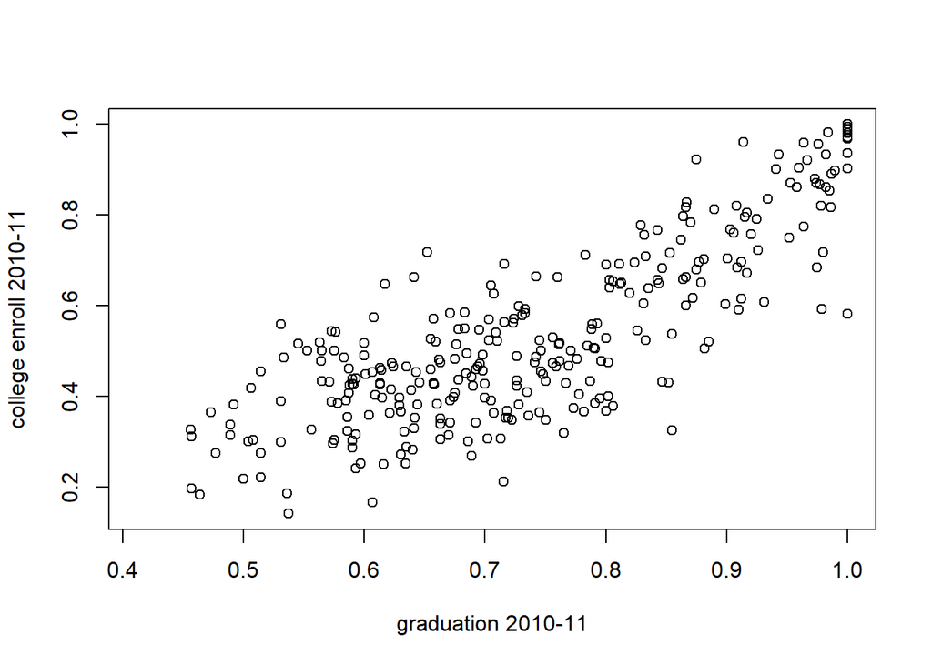

```r
graduationCollege <- school %>%
  select(`graduation 2010-11`, `college enroll 2010-11`)

plot(graduationCollege)
```

Once we have the data ready, then fitting the model is just easy-peasy by calling the `lm()` function.

In `lm()` function, you will first need to state the proposed model and use `~` to link the predicted variable and predictor variable together. Then, tell R that the data is from `graduationCollege`. Alternatively, you can use `$` to select the variables as what we have done in ICE2, but it is not necessary since we have already specified the `data =` parameter. Don’t forget to assign the model to one object. In this case, we use `model` to store the model information. Feel free to call it by different names. In practice, I prefer explicit names such as `collegeEnrollModel`. It will really help you remember things you are doing. See more style guide in here: http://adv-r.had.co.nz/Style.html

A side note, normally the dataset you work with might not have the spaces in column names, so you don’t always have to use `` `` ``.

Once you have build the model, you can call `summary()` to view the model statistics. R provide pretty comprehensive R summary that contains pretty much all you need. Notice that `model` here is a `list` object. It contains a lot of information, which might be useful to you for different purposes. Feel free to use `$` to see what is in it.

```r
model <- lm(`college enroll 2010-11`~`graduation 2010-11`, data = graduationCollege)
summary(model)
```

```
##
## Call:
## lm(formula = `college enroll 2010-11` ~ `graduation 2010-11`,
##     data = graduationCollege)
##
## Residuals:
##      Min       1Q   Median       3Q      Max
## -0.33512 -0.08226  0.00445  0.07970  0.28101
##
## Coefficients:
##                      Estimate Std. Error t value Pr(>|t|)
## (Intercept)          -0.27965    0.03603  -7.761 1.46e-13 ***
## `graduation 2010-11`  1.09915    0.04798  22.910  < 2e-16 ***
## ---
## Signif. codes:  0 '***' 0.001 '**' 0.01 '*' 0.05 '.' 0.1 ' ' 1
##
## Residual standard error: 0.1153 on 289 degrees of freedom
##   (131 observations deleted due to missingness)
## Multiple R-squared:  0.6449, Adjusted R-squared:  0.6437
## F-statistic: 524.9 on 1 and 289 DF,  p-value: < 2.2e-16
```

If you just need to coefficient information, then you can use `coef()` to extract. In the simple linear regression case, you will only have to values. Therefore, we can use `coef(model)[1]` to extract the intercept and `coef(model)[2]` to extract the slope.

`abline()` cannot work alone. This allows you to draw horizontal, vertical, or sloped lines. To draw the fitted line, you can specify `a` as the intercept and `b` as the slope, and `col` as the color of the line. Or just simply use `abline(model)`. But note that, `abline()` does not work alone. You have to run both lines together.

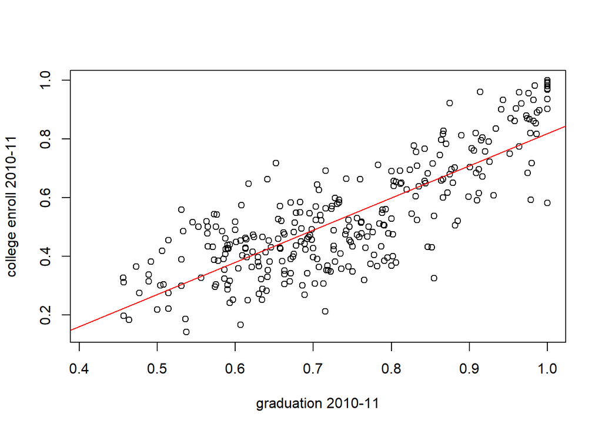

```r
plot(graduationCollege)

abline(a = coef(model)[1], b = coef(model)[2], col = "red") # Or you can simply do abline(model)
```

## A more realistic example with multiple independent variables

Here we are going to look at some interaction data from students watching on a class video. A project was proposed to collect data from student video watching, a sample of this data is available in the file `ICE3data.csv`.

- `stid` = student id
- `year` = year student watched video
- `participation` = whether or not the student opened the video
- `watch.time` = how long the student watched the video for
- `confusion.points` = how many times a student rewatched a section of a video
- `key.points` = how many times a student skipped or increased the speed of a video

Let’s see if we can build a regressor to predict how long the student will watch a video for.

```r
videoData = read_csv("ICE3_data.csv")
videoData
```

| stid | year | video | participation | watch.time | confusion.points | key.points |
| --- | --- | --- | --- | --- | --- | --- |
| 1 | 2018 | A | 1 | 16.50 | 6 | 6 |
| 2 | 2018 | A | 0 | 0.00 | 0 | 0 |
| 3 | 2018 | A | 1 | 9.00 | 4 | 6 |
| 4 | 2018 | A | 1 | 20.00 | 8 | 5 |
| 5 | 2018 | A | 1 | 12.00 | 8 | 5 |
| 6 | 2018 | A | 1 | 15.00 | 5 | 4 |
| 7 | 2018 | A | 1 | 24.75 | 11 | 5 |
| 8 | 2018 | A | 1 | 12.00 | 8 | 6 |
| 9 | 2018 | A | 1 | 15.00 | 5 | 2 |
| 10 | 2018 | A | 1 | 0.00 | 0 | 5 |

[output cut: 290 more lines]

You may want to call `summary` to first take a quick glance at what is going on. Obviously, we won’t be needing `stid` and `year`. And they should really be stored as categorical variables instead of numerical.

```r
summary(videoData)
```

```
##       stid            year         video           participation
##  Min.   : 1.00   Min.   :2018   Length:300         Min.   :0.0000
##  1st Qu.:15.75   1st Qu.:2018   Class :character   1st Qu.:0.0000
##  Median :30.50   Median :2018   Mode  :character   Median :1.0000
##  Mean   :30.50   Mean   :2018                      Mean   :0.7433
##  3rd Qu.:45.25   3rd Qu.:2019                      3rd Qu.:1.0000
##  Max.   :60.00   Max.   :2019                      Max.   :1.0000
##    watch.time     confusion.points   key.points
##  Min.   : 0.000   Min.   : 0.000   Min.   :0.000
##  1st Qu.: 0.000   1st Qu.: 0.000   1st Qu.:0.000
##  Median : 8.375   Median : 5.000   Median :2.000
##  Mean   : 9.303   Mean   : 4.427   Mean   :2.327
##  3rd Qu.:15.750   3rd Qu.: 8.000   3rd Qu.:4.000
##  Max.   :32.500   Max.   :13.000   Max.   :7.000
```

Next, let’s plot a scatter plot matrix to check the potential linearity among variables.

We are still using `plot()` to create this matrix.

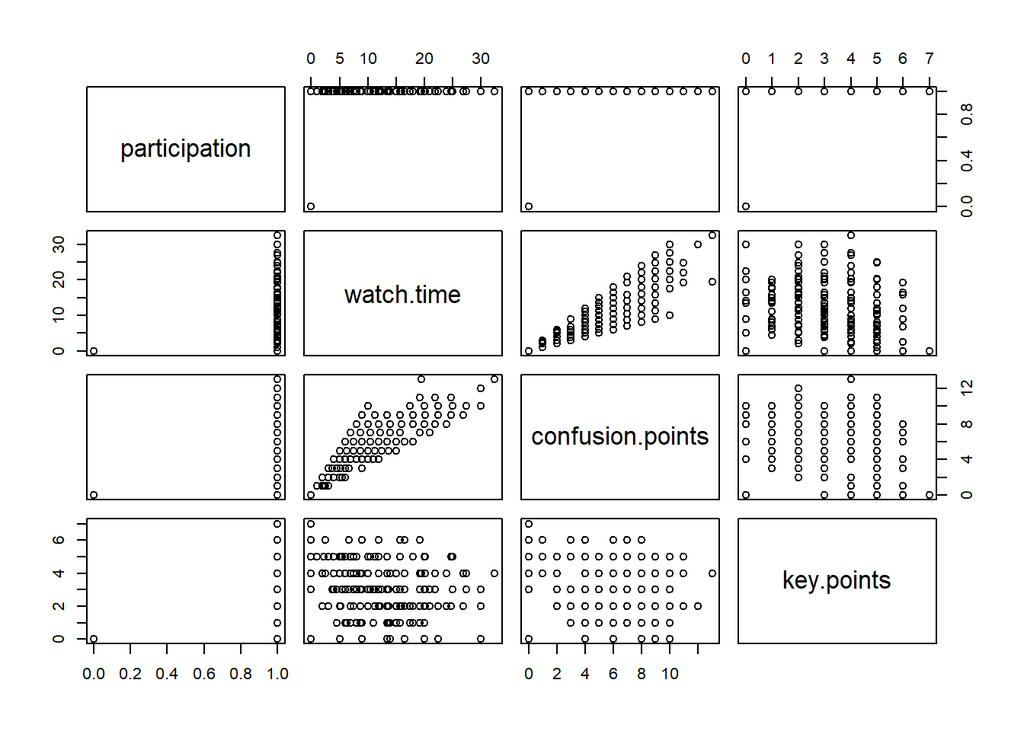

```r
videoDataRegression <- videoData %>% select(participation, watch.time, confusion.points, key.points)
plot(videoDataRegression)
```

If you want some fancier plots, you can try `pairs.panels()` in `psych()` package. You might need to install `psych()` before using.

```r
library(psych)
```

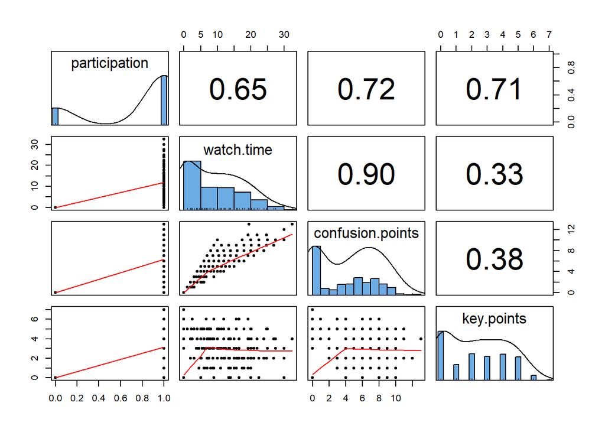

```r
pairs.panels(videoDataRegression,
             hist.col = "#6cace4", # You can use any color you like.
             ellipses= FALSE # FALSE turns off the correlation ellipses, but feel free to set it as TRUE or just leave it as default, which is TRUE
             )
```

**A small challenge for you**

From the scatter plot, it looks like watch time, confusion points, as well as key points are all not quite normal. Can you make them normal? You may need to `mutate()` variables.

```r
### NORMAL TRANFORMATION
### INSERT YOUR CODE HERE ###
```

For demonstration purpose, let’s just use all the variables to predict `watch.time`.

The process is no different than the simple linear model. Just this time, you have multiple Xs:

$$video Watch = b_0 + b_1 * participation + b_2 * confusion Points + b_3 * key Points$$
Once you know your formula, building a linear model in R is super easy, and you should feel very familiar.

```r
videoModel <- lm(watch.time ~ participation + confusion.points + key.points, data = videoDataRegression)
summary(videoModel)
```

```
##
## Call:
## lm(formula = watch.time ~ participation + confusion.points +
##     key.points, data = videoDataRegression)
##
## Residuals:
##     Min      1Q  Median      3Q     Max
## -10.675  -1.334   0.000   1.721   9.023
##
## Coefficients:
##                    Estimate Std. Error t value Pr(>|t|)
## (Intercept)       1.984e-14  4.100e-01   0.000    1.000
## participation     5.576e-01  9.398e-01   0.593    0.553
## confusion.points  2.087e+00  8.662e-02  24.097   <2e-16 ***
## key.points       -1.512e-01  1.603e-01  -0.943    0.346
## ---
## Signif. codes:  0 '***' 0.001 '**' 0.01 '*' 0.05 '.' 0.1 ' ' 1
##
## Residual standard error: 3.597 on 296 degrees of freedom
## Multiple R-squared:  0.8183, Adjusted R-squared:  0.8164
## F-statistic: 444.3 on 3 and 296 DF,  p-value: < 2.2e-16
```

```r
summary(model)
```

```
##
## Call:
## lm(formula = `college enroll 2010-11` ~ `graduation 2010-11`,
##     data = graduationCollege)
##
## Residuals:
##      Min       1Q   Median       3Q      Max
## -0.33512 -0.08226  0.00445  0.07970  0.28101
##
## Coefficients:
##                      Estimate Std. Error t value Pr(>|t|)
## (Intercept)          -0.27965    0.03603  -7.761 1.46e-13 ***
## `graduation 2010-11`  1.09915    0.04798  22.910  < 2e-16 ***
## ---
## Signif. codes:  0 '***' 0.001 '**' 0.01 '*' 0.05 '.' 0.1 ' ' 1
##
## Residual standard error: 0.1153 on 289 degrees of freedom
##   (131 observations deleted due to missingness)
## Multiple R-squared:  0.6449, Adjusted R-squared:  0.6437
## F-statistic: 524.9 on 1 and 289 DF,  p-value: < 2.2e-16
```

**Another small challenge for you**

How would interpret the results, How can we interpret individual features/predictors? What would you do next?

**For future readings on more advanced issues in regression**:

- **regularization in Python**: Regularization helps to solve over fitting problem. Simple model will be a very poor generalization of data. At the same time, complex model may not perform well in test data due to over fitting. We need to choose the right model in between simple and complex model (see here: https://www.r-bloggers.com/2017/07/machine-learning-explained-regularization/)
- **polynomial and non-linear regression**: Linearity is not always the case, so sometime we need non-linear models such as polynomial regression (see here:https://datascienceplus.com/fitting-polynomial-regression-r/) or other non-linear model such as decision tree (see here: https://www.datacamp.com/community/tutorials/decision-trees-R)
- **variable selection**: In real world analytics, we often come across a large volume of candidate regressors, but most end up not being useful in regression modeling. Finding the most appropriate set of regressors is a variable selection issue. (see here: https://www.statology.org/stepwise-regression-r/)

## Your Tasks for ICE 3

For ICE 3, you may want to: